# 07 - MANOVA

Francisco E. Fonturbel

24/October/2025

## Multivariate ANOVA

Until now, we operated ANOVA tests using one or more factors (or even a covariate) against a single response variable. But, what if we have two or more response variables? Is not rare that we measure several response attributes on a study system. So, if we have multiple response variables we could perform individual ANOVA tests for each response variable, but doing this represents two problems: (1) we cannot account for the global effect based on individual tests, and (2) we would have to correct our P-values for multiple comparisons.

Fortunately, there is an alternative for this: The Multivariate Analysis of Variance, aka **MANOVA**. Let’s see this example data:

```r
#Let's load the data file and libraries required
library(vegan)
library(MVN)

data<-read.table("data/07_manova.txt", header = T)
attach(data)
head(data)
```

```
##       Site ID_num     As_E      Cd_E     Pb_E     Sb_E     Sn_E     Cu_E
## 1 Polluted      1 2.705924 1.5608627 3.730488 3.155922 2.555584 2.377224
## 2 Polluted      2 1.828209 0.9263424 2.586250 2.359171 1.692171 1.824950
## 3 Polluted      3 2.495967 1.2646998 3.404062 3.498387 2.496106 2.578507
## 4 Polluted      4 2.554628 1.3031961 3.253717 2.684567 2.291580 2.099266
## 5 Polluted      5 2.040325 0.9228811 2.618752 1.670957 1.955126 1.837946
## 6 Polluted      6 1.884042 0.8744818 2.504339 1.705721 1.970517 1.831977
##       Zn_E     As_T     Cd_T     Pb_T     Sb_T     Sn_T     Cu_T     Zn_T
## 1 2.982730 3.420924 2.673334 4.791428 3.363044 2.553665 4.399236 5.283131
## 2 2.462498 2.595628 1.831486 3.685856 2.569058 1.998956 3.770566 4.849557
## 3 2.804657 3.250427 2.744097 4.812929 3.540855 2.645127 4.034835 4.828539
## 4 2.902865 3.363174 0.000000 4.116266 2.711655 2.659298 4.709082 5.392755
## 5 2.942659 2.109173 0.000000 3.413891 0.000000 1.716504 3.729100 4.826211
## 6 2.919218 1.611086 0.000000 3.491680 0.000000 1.321391 3.054046 4.200493
##       Sex Eat Contact
## 1   Males  No     Yes
## 2   Males Yes     Yes
## 3   Males Yes     Yes
## 4   Males Yes     Yes
## 5   Males  No      No
## 6 Females Yes     Yes
```

Our example presents data for polluted and non-polluted sites in which a rodent species occurs. We sampled seven heavy metals (Arsenic, Copper, Cadmium, Lead, Tin, Antimony, and Zinc) at the rodent tissue (_T samples) as well as in the soil (_E samples). So, we want to know if the heavy metal load (i.e., considering all elements together as response variable) vary between polluted and non-polluted sites. Also, we want to know if male and female rodents have different heavy metal loads, and if the contact or the consumption of plants from the polluted soil have an effect on heavy metal loads.

## Effects of the animal tissue

In this first part we will use metal concentration on the animal tissue as our response variable. For this, we must create a response vector first:

```r
y<-data[10:16]
```

Now, we will use the `manova` function and operate this just like a one-way ANOVA:

```r
manova0<-manova(as.matrix(y)~Site)
summary(manova0)
```

```
##           Df  Pillai approx F num Df den Df    Pr(>F)
## Site       1 0.63105   21.747      7     89 < 2.2e-16 ***
## Residuals 95
## ---
## Signif. codes:  0 '***' 0.001 '**' 0.01 '*' 0.05 '.' 0.1 ' ' 1
```

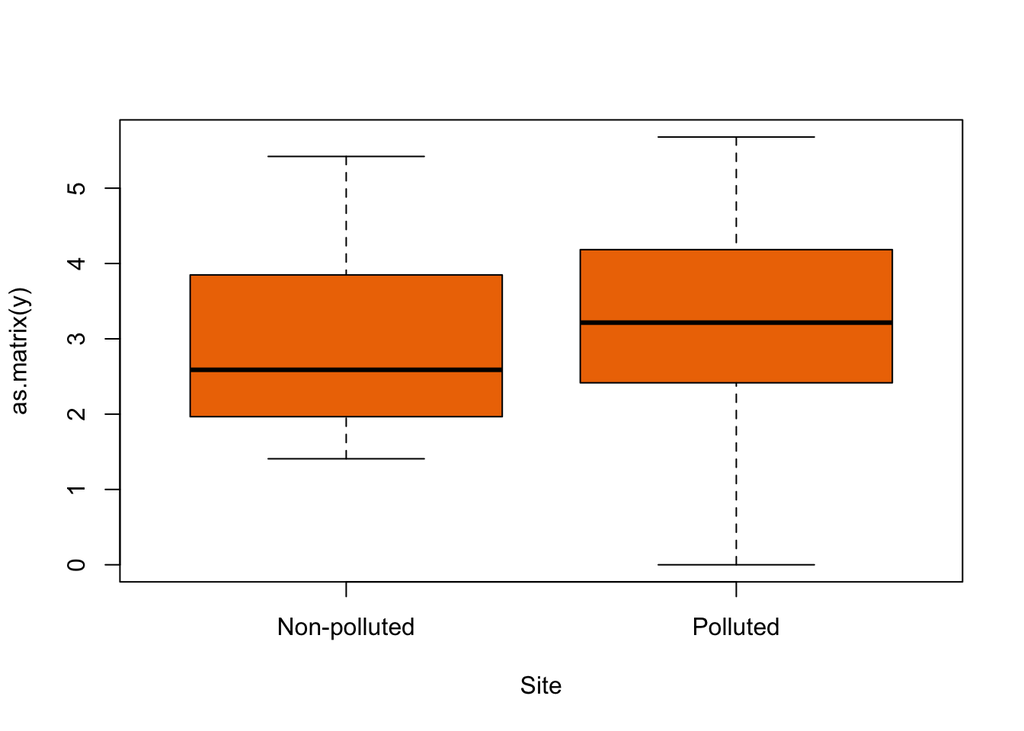

```r
boxplot(as.matrix(y)~Site, col ="darkorange2")
```

According to this result, the heavy metal loads are significantly different between polluted and non-polluted sites. While ANOVA reports the *F* statistic, MANOVA reports Pillai trace instead. However, there are other statistics that can be used with ANOVA, we just need to specify them in the code:

```r
summary(manova0, test="Wilks")
```

```
##           Df   Wilks approx F num Df den Df    Pr(>F)
## Site       1 0.36895   21.747      7     89 < 2.2e-16 ***
## Residuals 95
## ---
## Signif. codes:  0 '***' 0.001 '**' 0.01 '*' 0.05 '.' 0.1 ' ' 1
```

```r
summary(manova0, test="Roy")
```

```
##           Df    Roy approx F num Df den Df    Pr(>F)
## Site       1 1.7104   21.747      7     89 < 2.2e-16 ***
## Residuals 95
## ---
## Signif. codes:  0 '***' 0.001 '**' 0.01 '*' 0.05 '.' 0.1 ' ' 1
```

```r
summary(manova0, test="Hotelling-Lawley")
```

```
##           Df Hotelling-Lawley approx F num Df den Df    Pr(>F)
## Site       1           1.7104   21.747      7     89 < 2.2e-16 ***
## Residuals 95
## ---
## Signif. codes:  0 '***' 0.001 '**' 0.01 '*' 0.05 '.' 0.1 ' ' 1
```

The results are exactly the same, but we have different statistics in the report.

Wait… what if we want to know which metals have different between sites? Well, this can be easily answered by using the function `summary.aov` instead:

```r
summary.aov(manova0)
```

```
##  Response As_T :
##             Df  Sum Sq Mean Sq F value   Pr(>F)
## Site         1  2.3463 2.34632  12.764 0.000557 ***
## Residuals   95 17.4628 0.18382
## ---
## Signif. codes:  0 '***' 0.001 '**' 0.01 '*' 0.05 '.' 0.1 ' ' 1
##
##  Response Cd_T :
##             Df Sum Sq Mean Sq F value Pr(>F)
## Site         1  0.423 0.42293   0.773 0.3815
## Residuals   95 51.977 0.54713
##
##  Response Pb_T :
##             Df Sum Sq Mean Sq F value    Pr(>F)
## Site         1 19.466  19.466  121.68 < 2.2e-16 ***
## Residuals   95 15.198   0.160
## ---
## Signif. codes:  0 '***' 0.001 '**' 0.01 '*' 0.05 '.' 0.1 ' ' 1
##
##  Response Sb_T :
##             Df Sum Sq Mean Sq F value  Pr(>F)
## Site         1  3.105 3.10501  3.9725 0.04912 *
## Residuals   95 74.255 0.78163
## ---
## Signif. codes:  0 '***' 0.001 '**' 0.01 '*' 0.05 '.' 0.1 ' ' 1
##
##  Response Sn_T :
##             Df Sum Sq Mean Sq F value    Pr(>F)
## Site         1 3.8840  3.8840  43.966 2.024e-09 ***
## Residuals   95 8.3923  0.0883
## ---
## Signif. codes:  0 '***' 0.001 '**' 0.01 '*' 0.05 '.' 0.1 ' ' 1
##
##  Response Cu_T :
##             Df  Sum Sq Mean Sq F value   Pr(>F)
## Site         1  0.8953 0.89527  8.3732 0.004723 **
## Residuals   95 10.1575 0.10692
## ---
## Signif. codes:  0 '***' 0.001 '**' 0.01 '*' 0.05 '.' 0.1 ' ' 1
##
##  Response Zn_T :
##             Df Sum Sq Mean Sq F value Pr(>F)
## Site         1 0.1078 0.10783  1.1416  0.288
## Residuals   95 8.9737 0.09446
```

Awesome! with this code we can determine that Cd and Zn are not different between sites, but the other metals present significant differences.

### Assumptions

As happens with ANOVA, MANOVA relies on some assumptions. Let’s take a look to these plots first:

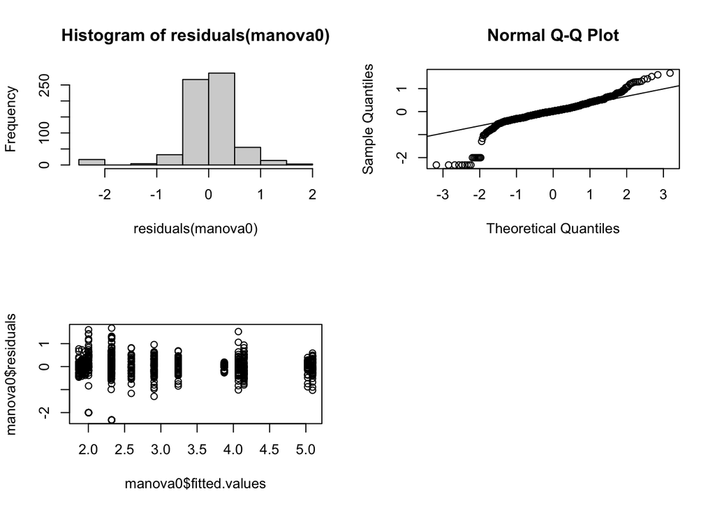

```r
par(mfcol=c(2,2))
hist(residuals(manova0))
plot(manova0$residuals~manova0$fitted.values)
qqnorm(manova0$residuals)
qqline(manova0$residuals)
par(mfcol=c(1,1))
```

Uhmm… it seems that our data is not normal. Let’s use the `mvn` function from the `MVN` package to test it:

```r
multinorm<-mvn(y, mvn_test = "royston")
multinorm
```

```
## $multivariate_normality
##      Test Statistic p.value     Method          MVN
## 1 Royston    90.654  <0.001 asymptotic ✗ Not normal
##
## $univariate_normality
##               Test Variable Statistic p.value    Normality
## 1 Anderson-Darling     As_T     0.209   0.859     ✓ Normal
## 2 Anderson-Darling     Cd_T     4.435  <0.001 ✗ Not normal
## 3 Anderson-Darling     Pb_T     0.350   0.466     ✓ Normal
## 4 Anderson-Darling     Sb_T     3.541  <0.001 ✗ Not normal
## 5 Anderson-Darling     Sn_T     0.412   0.334     ✓ Normal
## 6 Anderson-Darling     Cu_T     2.250  <0.001 ✗ Not normal
## 7 Anderson-Darling     Zn_T     1.134   0.005 ✗ Not normal
##
## $descriptives
```

[output cut: 117 more lines]

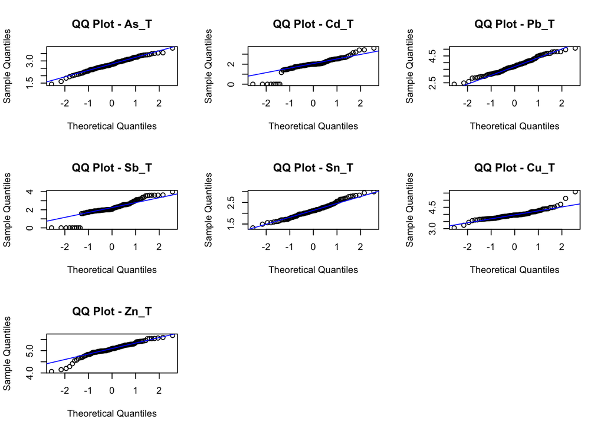

```r
par(mfrow=c(3,3))
for(i in 1:ncol(y)){
  qqnorm(y[,i], main = paste("QQ Plot -", names(y)[i]))
  qqline(y[,i], col = "blue")
}
par(mfrow=c(1,1))
```

So, we have some normality issues. As an alternative, there is a non-parametric version of MANOVA. We will use the function `adonis` from the `vegan` package to do this:

```r
manova0np<-adonis2(as.matrix(y)~Site)
manova0np
```

```
## Permutation test for adonis under reduced model
## Permutation: free
## Number of permutations: 999
##
## adonis2(formula = as.matrix(y) ~ Site)
##          Df SumOfSqs      R2      F Pr(>F)
## Model     1  0.09900 0.19435 22.917  0.001 ***
## Residual 95  0.41040 0.80565
## Total    96  0.50941 1.00000
## ---
## Signif. codes:  0 '***' 0.001 '**' 0.01 '*' 0.05 '.' 0.1 ' ' 1
```

The non-parametric test confirmed our results.

### Testing the other factors

Now that we know that factor *Site* is important, let’s examine the other factors:

**Contact with polluted plants**

```r
manova1<-manova(as.matrix(y)~Contact)
summary(manova1)
```

```
##           Df   Pillai approx F num Df den Df Pr(>F)
## Contact    1 0.077396   1.0666      7     89 0.3916
## Residuals 95
```

No effect of contact.

**Eating polluted plants**

```r
manova2<-manova(as.matrix(y)~Eat)
summary(manova2)
```

```
##           Df  Pillai approx F num Df den Df Pr(>F)
## Eat        1 0.11478   1.6486      7     89 0.1322
## Residuals 95
```

No effect as well.

**Males versus females**

```r
manova3<-manova(as.matrix(y)~Sex)
summary(manova3)
```

```
##           Df  Pillai approx F num Df den Df   Pr(>F)
## Sex        1 0.20182   3.2148      7     89 0.004391 **
## Residuals 95
## ---
## Signif. codes:  0 '***' 0.001 '**' 0.01 '*' 0.05 '.' 0.1 ' ' 1
```

And now we have a significant effect of animal sex on metal loads. Let’s make a boxplot:

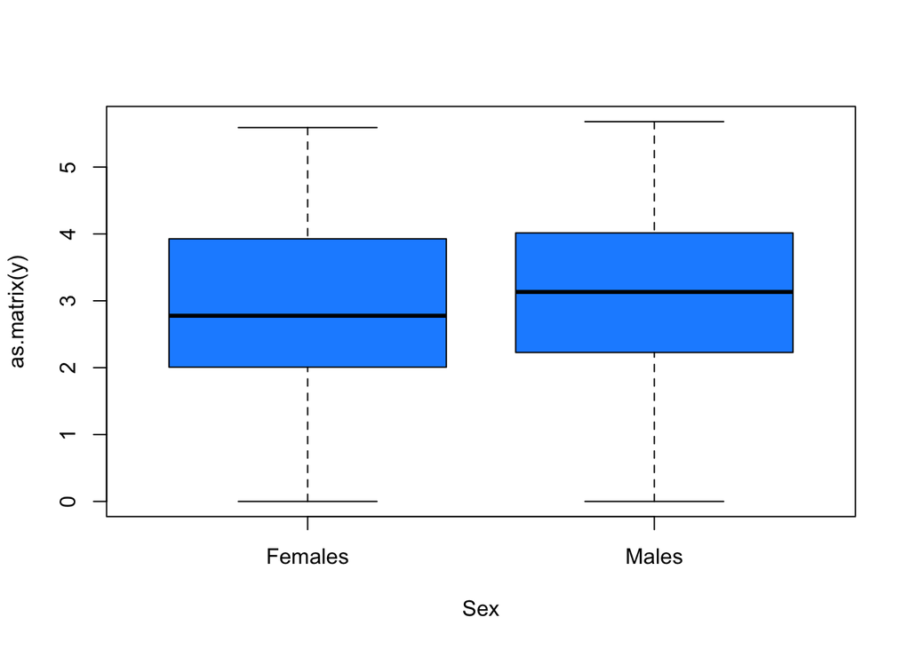

```r
boxplot(as.matrix(y)~Sex, col = "dodgerblue1")
```

### Interactions

As with ANOVA, we can have more than one factor in the model and estimate their interactions:

```r
manova4<-manova(as.matrix(y)~Site*Sex)
summary(manova4)
```

```
##           Df  Pillai approx F num Df den Df  Pr(>F)
## Site       1 0.63821  21.9245      7     87 < 2e-16 ***
## Sex        1 0.17388   2.6159      7     87 0.01686 *
## Site:Sex   1 0.07528   1.0118      7     87 0.42872
## Residuals 93
## ---
## Signif. codes:  0 '***' 0.001 '**' 0.01 '*' 0.05 '.' 0.1 ' ' 1
```

## Effects on the environment

Now, we will repeat the analyses using the data from soil samples instead.

```r
d<-data[3:9]
```

Now that we have our new response vector, we repeat the site MANOVA:

```r
manovad<-manova(as.matrix(d)~Site)
summary(manovad)
```

```
##           Df  Pillai approx F num Df den Df    Pr(>F)
## Site       1 0.40023   8.4842      7     89 6.357e-08 ***
## Residuals 95
## ---
## Signif. codes:  0 '***' 0.001 '**' 0.01 '*' 0.05 '.' 0.1 ' ' 1
```

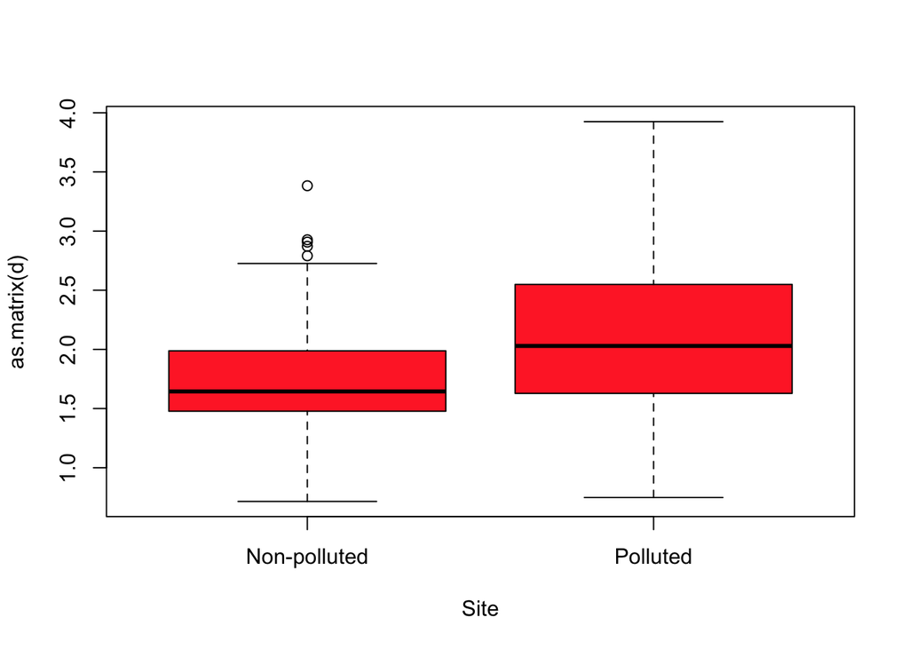

```r
boxplot(as.matrix(d)~Site, col = "firebrick1")
```

We can also examine the individual responses:

```r
summary.aov(manovad)
```

```
##  Response As_E :
##             Df  Sum Sq Mean Sq F value    Pr(>F)
## Site         1  2.4968 2.49680  23.519 4.826e-06 ***
## Residuals   95 10.0854 0.10616
## ---
## Signif. codes:  0 '***' 0.001 '**' 0.01 '*' 0.05 '.' 0.1 ' ' 1
##
##  Response Cd_E :
##             Df Sum Sq Mean Sq F value    Pr(>F)
## Site         1 1.5930 1.59300  30.833 2.547e-07 ***
## Residuals   95 4.9082 0.05167
## ---
## Signif. codes:  0 '***' 0.001 '**' 0.01 '*' 0.05 '.' 0.1 ' ' 1
##
##  Response Pb_E :
##             Df Sum Sq Mean Sq F value    Pr(>F)
## Site         1 10.278  10.278  46.934 7.267e-10 ***
## Residuals   95 20.805   0.219
## ---
## Signif. codes:  0 '***' 0.001 '**' 0.01 '*' 0.05 '.' 0.1 ' ' 1
##
##  Response Sb_E :
##             Df  Sum Sq Mean Sq F value    Pr(>F)
## Site         1  7.8421  7.8421  32.902 1.148e-07 ***
## Residuals   95 22.6433  0.2384
## ---
## Signif. codes:  0 '***' 0.001 '**' 0.01 '*' 0.05 '.' 0.1 ' ' 1
##
##  Response Sn_E :
##             Df Sum Sq Mean Sq F value    Pr(>F)
## Site         1 2.7810 2.78104  36.227 3.282e-08 ***
## Residuals   95 7.2928 0.07677
## ---
## Signif. codes:  0 '***' 0.001 '**' 0.01 '*' 0.05 '.' 0.1 ' ' 1
##
##  Response Cu_E :
##             Df Sum Sq Mean Sq F value   Pr(>F)
## Site         1 0.8698 0.86978   10.14 0.001962 **
## Residuals   95 8.1488 0.08578
## ---
## Signif. codes:  0 '***' 0.001 '**' 0.01 '*' 0.05 '.' 0.1 ' ' 1
##
##  Response Zn_E :
##             Df Sum Sq Mean Sq F value    Pr(>F)
## Site         1 1.9786 1.97864  26.881 1.218e-06 ***
## Residuals   95 6.9928 0.07361
## ---
## Signif. codes:  0 '***' 0.001 '**' 0.01 '*' 0.05 '.' 0.1 ' ' 1
```

In this case, all elements have significantly different concentrations in the soil between sites.

### Testing the other factors

**Contact with polluted plants**

```r
manova5<-manova(as.matrix(d)~Contact)
summary(manova5)
```

```
##           Df   Pillai approx F num Df den Df Pr(>F)
## Contact    1 0.042559  0.56516      7     89 0.7823
## Residuals 95
```

No effect of contact.

**Eating polluted plants**

```r
manova6<-manova(as.matrix(d)~Eat)
summary(manova6)
```

```
##           Df   Pillai approx F num Df den Df Pr(>F)
## Eat        1 0.082433   1.1422      7     89 0.3443
## Residuals 95
```

No effect as well.

**Males versus females**

```r
manova7<-manova(as.matrix(d)~Sex)
summary(manova7)
```

```
##           Df  Pillai approx F num Df den Df Pr(>F)
## Sex        1 0.11128   1.5919      7     89 0.1481
## Residuals 95
```

And no effect as well.

## Final thoughts

MANOVA is a very good alternative when we have multiple response variables and we want to assess the overall effect. In operational terms, MANOVA is operated pretty much like ANOVA. The only missing thing here are the *a posteriori* tests, as they are not available (yet) for MANOVA.

Licensing Creative Commons License

Licensed under a Creative Commons Attribution-ShareAlike 4.0 International License.  
2025 - Francisco E. Fontúrbel